# Extracting and Visualizing Stock Data

## Question 6: Plot GameStop Stock Graph

Use the `make_graph` function to graph the GameStop Stock Data, also provide a title for the graph. The structure to call the `make_graph` function is `make_graph(gme_data, gme_revenue, 'GameStop')`. Note the graph will only show data upto June 2021.

**Hint**

```
You just need to invoke the make_graph function with the required parameter to print the graphs.The structure to call the `make_graph` function is `make_graph(gme_data, gme_revenue, 'GameStop')`
```

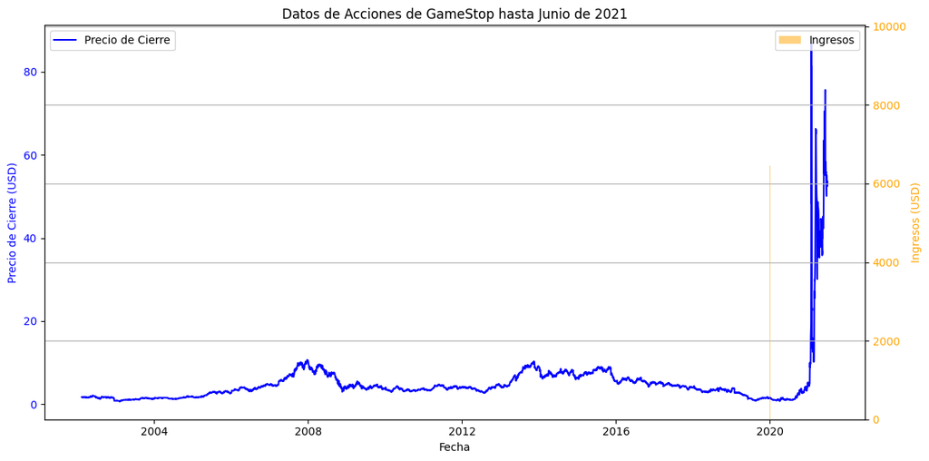

```python
gme_data['Date'] = pd.to_datetime(gme_data['Date'])
gme_revenue['Date'] = pd.to_datetime(gme_revenue['Date'])

# Filtrar datos hasta junio de 2021
gme_data_filtered = gme_data[gme_data['Date'] <= '2021-06-30']
gme_revenue_filtered = gme_revenue[gme_revenue['Date'] <= '2021-06-30']

# Función para graficar con eje y secundario
def make_graph(data, revenue, title):
    fig, ax1 = plt.subplots(figsize=(12, 6))

    # Graficar los precios de cierre
    ax1.plot(data['Date'], data['Close'], label='Precio de Cierre', color='blue')
    ax1.set_xlabel('Fecha')
    ax1.set_ylabel('Precio de Cierre (USD)', color='blue')
    ax1.tick_params(axis='y', labelcolor='blue')

    # Crear un eje y secundario para los ingresos
    ax2 = ax1.twinx()
    ax2.bar(revenue['Date'], revenue['Revenue'].astype(float), label='Ingresos', color='orange', alpha=0.5)
    ax2.set_ylabel('Ingresos (USD)', color='orange')
    ax2.tick_params(axis='y', labelcolor='orange')

    # Configuraciones del gráfico
    plt.title(f'Datos de Acciones de {title} hasta Junio de 2021')
    ax1.legend(loc='upper left')
    ax2.legend(loc='upper right')
    plt.xticks(rotation=45)
    plt.grid()
    plt.tight_layout()
    plt.show()

# Llamar a la función para graficar
make_graph(gme_data_filtered, gme_revenue_filtered, 'GameStop')
```

## About the Authors:

[Joseph Santarcangelo](https://www.linkedin.com/in/joseph-s-50398b136/) has a PhD in Electrical Engineering, his research focused on using machine learning, signal processing, and computer vision to determine how videos impact human cognition. Joseph has been working for IBM since he completed his PhD.

[output not shown]

[output not shown]

[output not shown]

[output not shown]

[output not shown]

[output not shown]